# html

## Questions 1:

**Data Cleaning & Exploration Questions**

**Scenario:** You're presented with the sales data for the last year. There have been multiple complaints from customers regarding certain sellers. To understand this better, you decide to begin by cleaning and exploring the data.

**Task:** Identify and handle any missing values and outliers in the `Sales` table, especially focusing on `sale_amount`. Use visual tools to help you explore patterns. What insights can you derive regarding the sale amounts and return rates?

## Solution

### **Hint:**

1. **Data Cleaning & Exploration**:
   - Check for missing values in the Sales table.
   - Explore the distribution of the `sale_amount` using plots.
   - Identify and treat outliers for the `sale_amount`.
   - Check the return rate and its relation to `sale_amount`.
2. **Interpretation**:
   - Plot distribution charts and correlation plots.
   - Comment on the patterns observed.

### Step 1: Data Cleaning & Exploration

**1.1 Check for missing values in Sales table**

```python
# Check for missing values
missing_values = df_sales.isnull().sum()
print(missing_values)
```

```
transaction_id     0
seller_id          0
product_id         0
sale_date          0
sale_amount       10
is_returned        0
dtype: int64
```

`sale_amount` is not necessary to predict and we don't want to arbitrarily fill in the blank values, and deleting a few rows won't affect the analysis, so we chose to drop those rows.

```python
# Remove rows with missing 'sale_amount'
df_sales.dropna(subset=['sale_amount'], inplace=True)
```

**1.2 Explore distribution of the `sale_amount`**

Before treating outliers, it's essential to understand the distribution of the variable.

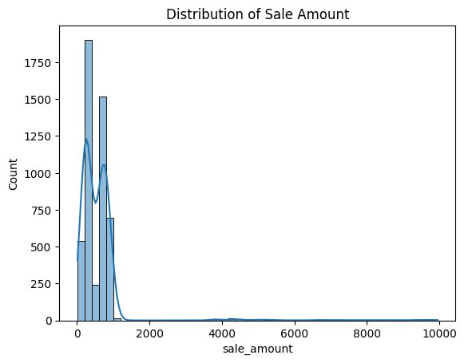

```python
import matplotlib.pyplot as plt
import seaborn as sns

# Plot distribution
sns.histplot(df_sales['sale_amount'], bins=50, kde=True)
plt.title('Distribution of Sale Amount')
plt.show()
```

**1.3 Identify and treat outliers for `sale_amount`**

Use the IQR (Interquartile Range) method to detect outliers.

```python
# Calculate IQR
Q1 = df_sales['sale_amount'].quantile(0.25)
Q3 = df_sales['sale_amount'].quantile(0.75)
IQR = Q3 - Q1

# Define bounds
lower_bound = Q1 - 1.5 * IQR
upper_bound = Q3 + 1.5 * IQR

# Filter out outliers
df_sales_cleaned = df_sales[(df_sales['sale_amount'] >= lower_bound) & (df_sales['sale_amount'] <= upper_bound)]
```

Visulize the outliers by using boxplot:

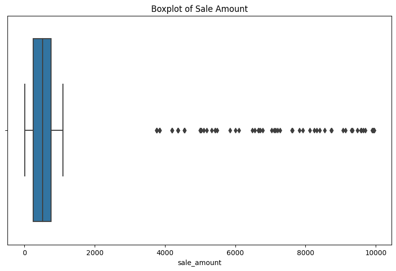

```python
# Boxplot
plt.figure(figsize=(10, 6))
sns.boxplot(x=df_sales['sale_amount'])
plt.title('Boxplot of Sale Amount')
plt.show()
```

**1.4 Check return rate and its relation to `sale_amount`**

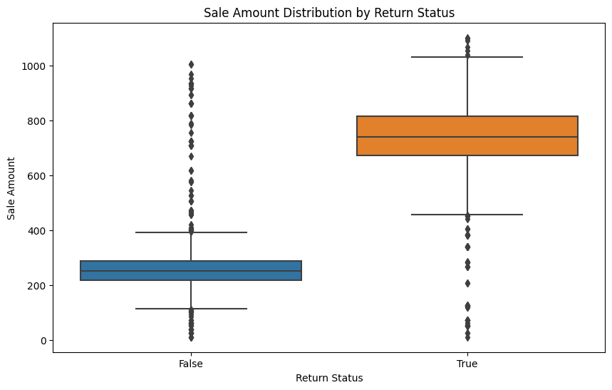

```python
plt.figure(figsize=(10, 6))
sns.boxplot(x=df_sales_cleaned['is_returned'], y=df_sales_cleaned['sale_amount'])
plt.title('Sale Amount Distribution by Return Status')
plt.xlabel('Return Status')
plt.ylabel('Sale Amount')
plt.show()
```

### Step 2: Interpretation

**2.2 Comment on outliers**

**2.3 Sale Amount vs. Return Status**

From the observed data:

- Transactions that haven't been returned (Return Status = 0) predominantly lie in the 200-300 price range. This could suggest that items within this price bracket are generally satisfactory to customers or perhaps are less risky purchases.
- On the other hand, items that have been returned (Return Status = 1) show a concentration in the 700-800 price range. This higher price range for returns could be indicative of various factors. Customers might be more cautious or discerning with higher-priced items, leading to more returns. Alternatively, higher-value items might come with higher expectations, and any deviation might prompt a return.

**General Insights**:

- The distinct price ranges associated with return statuses suggest varying customer behaviors or expectations at different price points. It may be beneficial for the business to dig deeper into the nature of products in these ranges and assess if specific product categories or attributes lead to more returns, especially in the higher price ranges.
- A pattern where higher sale amounts are associated with a higher return rate could hint at potential issues in product quality, descriptions, or customer expectations at those price points. Addressing these issues can lead to improved customer satisfaction and reduced return rates.

## Questions 2:

**SQL Queries Questions**

**Scenario:** You've been informed that some sellers might be listing their products under multiple IDs to manipulate sales numbers. You decide to explore this by diving into the sales data.

**Task:** Using the `Sales` and `Sellers` tables, identify sellers who have more than one product ID associated with a high return rate. Combine the information of these sellers and products, ensuring there are no duplicates. Finally, join the tables in a way to highlight these sellers and their associated product IDs, focusing on those who joined in the last year.

## Solution

### **Hint:**

1. **Table Creation and Data Ingestion**:
   - Initialize a SQLite database connection in Colab.
   - Ingest the `Sellers` and `Sales` tables into the SQLite database.
2. **Data Exploration**:
   - Analyze the tables to understand their structure.
   - Check for missing or anomalous data.
3. **Identify Sellers with Multiple Product IDs and High Return Rate**:
   - Use SQL to compute the return rate for each product associated with each seller.
   - Identify sellers who have more than one product with high return rates.
4. **Join & Filter Data**:
   - Join the identified sellers and products, ensuring there are no duplicates.
   - Filter results to sellers who joined within the last year.

### Step 1: Table Creation and Data Ingestion

```python
# Load the SQL extension:
%load_ext sql

# Connect to SQLite:
%sql sqlite:///example.db

import sqlite3

# Connect to the SQLite database
conn = sqlite3.connect('example.db')

# Assuming the dataframes are named df_sellers and df_sales
df_sellers.to_sql('Sellers', conn, if_exists='replace', index=False)
df_sales.to_sql('Sales', conn, if_exists='replace', index=False)
```

### Step 2: Data Exploration

```python
%%sql
-- Display the first 5 rows of the Sellers table
SELECT * FROM Sellers LIMIT 5;
```

```
 * sqlite:///example.db
Done.
```

| seller_id | join_date | avg_customer_rating | total_sales_last_month | return_rate |
| --- | --- | --- | --- | --- |
| 1 | 2021-06-09 00:00:00 | 2.074818864551044 | 0 | 0.0 |
| 2 | 2021-08-07 00:00:00 | 4.385336041236596 | 2 | 0.2 |
| 3 | 2020-08-21 00:00:00 | 2.7719834429186565 | 0 | 0.6666666666666666 |
| 4 | 2021-08-15 00:00:00 | 4.056540158337218 | 0 | 0.375 |
| 5 | 2017-01-16 00:00:00 | 2.0782891914351533 | 0 | 0.6 |

```python
%%sql
-- Display the first 5 rows of the Sales table
SELECT * FROM Sales LIMIT 5
```

```
 * sqlite:///example.db
Done.
```

| transaction_id | seller_id | product_id | sale_date | sale_amount | is_returned |
| --- | --- | --- | --- | --- | --- |
| 1 | 242 | 4 | 2023-08-08 | 583.8411231862099 | 1 |
| 2 | 699 | 582 | 2023-09-08 | 769.8845676557349 | 1 |
| 3 | 862 | 999 | 2022-12-04 | 178.69597789608582 | 0 |
| 4 | 217 | 1279 | 2023-04-22 | 800.4638430768238 | 1 |
| 5 | 121 | 1605 | 2023-03-20 | 273.7644727616663 | 0 |

### Step 3: Identify Sellers with Multiple Product IDs and High Return Rate

We assume a "high return rate" is anything greater than 70%.

```python
%%sql
WITH ReturnRates AS (
    SELECT
        seller_id,
        product_id,
        SUM(CASE WHEN is_returned = 1 THEN 1 ELSE 0 END) AS num_returns,
        COUNT(transaction_id) AS total_sales,
        (SUM(CASE WHEN is_returned = 1 THEN 1 ELSE 0 END) * 1.0 / COUNT(transaction_id)) AS return_rate
    FROM Sales
    GROUP BY seller_id, product_id
    HAVING return_rate > 0.7
)

SELECT
    DISTINCT r.seller_id,
    r.product_id
FROM ReturnRates r
JOIN Sellers s ON r.seller_id = s.seller_id
WHERE strftime('%Y', 'now') - strftime('%Y', s.join_date) <= 1;
```

```
 * sqlite:///example.db
Done.
```

| seller_id | product_id |
| --- | --- |
| 6 | 1836 |
| 16 | 97 |
| 16 | 335 |
| 16 | 873 |
| 16 | 1188 |
| 19 | 1248 |
| 19 | 1857 |
| 20 | 284 |
| 20 | 1209 |
| 20 | 1404 |
| 20 | 1419 |
| 24 | 271 |
| 24 | 353 |
| 24 | 1790 |
| 25 | 679 |
| 25 | 1431 |
| 26 | 188 |
| 26 | 802 |
| 26 | 1235 |
| 27 | 167 |
| 32 | 935 |
| 32 | 1095 |
| 33 | 1174 |
| 33 | 1364 |
| 33 | 1672 |
| 33 | 1772 |
| 35 | 346 |
| 35 | 398 |
| 35 | 696 |
| 35 | 1949 |

[output cut: 707 more lines]

## Question 3:

**Probability and Statistical Analysis Questions**

**Scenario:** To better understand the behavior of new sellers, you hypothesize that sellers who join the platform and immediately have high sales are more likely to be involved in fraudulent activities.

**Task:** Calculate the probability that a new seller (joined in the last month) will have sales in the top 10% of all sellers in their first month. Validate your hypothesis using the appropriate statistical tests on the `Sellers` table, making sure to consider potential over-fitting. Code the calculation to obtain the result.

## Solution

### **Hint:**

1. **Data Preprocessing**:
   - Extract new sellers from the `Sellers` table.
   - Calculate the sales threshold for the top 10% of all sellers.
2. **Probability Calculation**:
   - Compute the probability that a new seller will have sales in the top 10%.
3. **Statistical Test**:
   - Use an appropriate statistical test to validate the hypothesis.
4. **Overfitting Consideration**:
   - Discuss potential overfitting and how to mitigate it.

### Step 1: Identify New Sellers

First, we need to identify the sellers who have joined in the last month.

```python
from datetime import datetime

# Convert the join_date column to datetime
df_sellers['join_date'] = pd.to_datetime(df_sellers['join_date']).dt.date

# Get today's date
today = datetime.now().date()

# Filter sellers who joined in the last month
new_sellers = df_sellers[df_sellers['join_date'] > (today - pd.Timedelta(days=30))]
new_seller_ids = new_sellers['seller_id'].unique()
```

### Step 2: Calculate Total Sales for These New Sellers in Their First Month

```python
# Filter sales for these new sellers
new_sellers_sales = df_sales[df_sales['seller_id'].isin(new_seller_ids)]

# Sum sales for each seller
new_sellers_monthly_sales = new_sellers_sales.groupby('seller_id')['sale_amount'].sum()
```

### Step 3: Determine the Sales Threshold for Top 10% of All Sellers

```python
# Calculate the sales for all sellers in the last month
df_sales['sale_date'] = pd.to_datetime(df_sales['sale_date']).dt.date
all_sellers_last_month_sales = df_sales[df_sales['sale_date'] > (today - pd.Timedelta(days=30))]
total_sales_per_seller = all_sellers_last_month_sales.groupby('seller_id')['sale_amount'].sum()

# Determine the 90th percentile sales value
top_10_percent_threshold = total_sales_per_seller.quantile(0.9)
```

```python
print(f"Number of sellers who joined in the last month: {len(new_seller_ids)}")
```

```
Number of sellers who joined in the last month: 52
```

### Step 4: Calculate the Probability

```python
# Check how many new sellers have sales in the top 10%
top_sellers_count = (new_sellers_monthly_sales > top_10_percent_threshold).sum()

# Calculate the probability
probability = top_sellers_count / len(new_sellers_monthly_sales)

print(f"Probability that a new seller will have sales in the top 10%: {probability:.2f}")
```

```
Probability that a new seller will have sales in the top 10%: 0.21
```

### Step 5: Statistical Test (One-Sample Z-test)

To validate the hypothesis, we can conduct a one-sample z-test. We'll compare the average sales of new sellers against the average sales of all sellers. If new sellers have a statistically significant higher average, it supports our hypothesis. We'll use a significance level of (alpha = 0.05).

```python
from scipy import stats
import numpy as np

# Calculate the population mean and standard deviation
population_mean = total_sales_per_seller.mean()
population_std = total_sales_per_seller.std()

# Calculate the sample mean
sample_mean = new_sellers_monthly_sales.mean()

# Calculate the z-statistic
z = (sample_mean - population_mean) / (population_std/np.sqrt(len(new_sellers_monthly_sales)))

# Calculate the p-value
p_value = 1 - stats.norm.cdf(z)

print(f"Z-statistic: {z:.2f}")
print(f"P-value: {p_value:.4f}")
```

```
Z-statistic: 13.69
P-value: 0.0000
```

Based on the results of the statistical test, the p-value is 0.0000, which is significantly less than the threshold value of 0.05. This allows us to reject the null hypothesis. Consequently, we can conclude that new sellers have a sales average that is statistically different from that of the general population of sellers. The evidence suggests that there is a significant difference in the sales performance between new sellers and the broader group of sellers.

## Question 4:

**Product & Business Sense Questions**

**Scenario:** Recently, the platform predicted that the revenue from the marketplace will increase by 15%, but the actual revenue increased by only 5%.

**Task:** Using the `Sales` and `Sellers` tables, analyze the data to pinpoint potential reasons for this discrepancy. Identify key metrics (like return rate, average customer rating, etc.) that might have influenced this difference. Based on your analysis, what recommendations can you provide to bridge the gap between the predicted and actual revenue in the future?

## Solution

### 1. Data Preparation & Overview

Ensure that the dataset is correctly formatted and cleaned. Check for missing values, duplicates, or any anomalies.

```python
# Check for missing values
print(df_sales.isnull().sum())
print(df_sellers.isnull().sum())

# Remove duplicates and drop rows contain missing values, if any
df_sales.drop_duplicates(inplace=True)
df_sellers.drop_duplicates(inplace=True)
df_sellers.dropna(subset=['avg_customer_rating'], inplace=True)
df_sellers.dropna(subset=['return_rate'], inplace=True)

# Recheck for missing values
print(df_sales.isnull().sum())
print(df_sellers.isnull().sum())
```

```
transaction_id    0
seller_id         0
product_id        0
sale_date         0
sale_amount       0
is_returned       0
dtype: int64
seller_id                  0
join_date                  0
avg_customer_rating       10
total_sales_last_month     0
return_rate               36
dtype: int64
transaction_id    0
seller_id         0
product_id        0
sale_date         0
sale_amount       0
is_returned       0
dtype: int64
seller_id                 0
join_date                 0
avg_customer_rating       0
total_sales_last_month    0
return_rate               0
dtype: int64
```

### 2. Investigate Revenue Sources

A good starting point is to check if there are particular sources of revenue that have declined or not grown as expected.

#### a) Breakdown of Sales by New Sellers vs. Established Sellers:

```python
# Sum sales amounts for new and established sellers
new_sellers_sales = df_Sales[df_Sales['seller_id'].isin(new_sellers_ids)]['sale_amount'].sum()
established_sellers_sales = df_Sales[~df_Sales['seller_id'].isin(new_sellers_ids)]['sale_amount'].sum()

print(f"Revenue from New Sellers: ${new_sellers_sales:.2f}")
print(f"Revenue from Established Sellers: ${established_sellers_sales:.2f}")
```

```
Revenue from New Sellers: $265508.36
Revenue from Established Sellers: $2715009.51
```

#### b) Examine the Return Rate:

High return rates can affect revenue. Compare the return rate of new sellers to established sellers.

```python
new_sellers_return_rate = df_Sales[df_Sales['seller_id'].isin(new_sellers_ids)]['is_returned'].mean()
established_sellers_return_rate = df_Sales[~df_Sales['seller_id'].isin(new_sellers_ids)]['is_returned'].mean()

print(f"Return Rate of New Sellers: {new_sellers_return_rate*100:.2f}%")
print(f"Return Rate of Established Sellers: {established_sellers_return_rate*100:.2f}%")
```

```
Return Rate of New Sellers: 53.60%
Return Rate of Established Sellers: 49.86%
```

### 3. Investigate Key Metrics

#### a) Average Customer Rating:

Low ratings can decrease a seller's sales.

```python
average_rating_new = df_Sellers[df_Sellers['seller_id'].isin(new_sellers_ids)]['avg_customer_rating'].mean()
average_rating_established = df_Sellers[~df_Sellers['seller_id'].isin(new_sellers_ids)]['avg_customer_rating'].mean()

print(f"Average Rating of New Sellers: {average_rating_new:.2f}")
print(f"Average Rating of Established Sellers: {average_rating_established:.2f}")
```

```
Average Rating of New Sellers: 3.30
Average Rating of Established Sellers: 2.95
```

#### b) Product Diversity:

A limited range of products might hinder revenue growth. Check if new sellers are diversifying their product offerings.

```python
unique_products_new = df_Sales[df_Sales['seller_id'].isin(new_sellers_ids)]['product_id'].nunique()
unique_products_established = df_Sales[~df_Sales['seller_id'].isin(new_sellers_ids)]['product_id'].nunique()

print(f"Number of Unique Products from New Sellers: {unique_products_new}")
print(f"Number of Unique Products from Established Sellers: {unique_products_established}")
```

```
Number of Unique Products from New Sellers: 234
Number of Unique Products from Established Sellers: 1827
```

### Insights:

1. **Product Diversity**: New sellers have a significantly smaller product range (234 unique products) compared to established sellers (1827 unique products). This difference indicates that new sellers are not diversifying their product offerings as much as they could.
2. **Average Customer Rating**: Interestingly, new sellers (3.30 average rating) have a slightly higher average customer rating than established sellers (2.95 average rating). This suggests that while newer sellers are delivering a satisfactory customer experience, there's room for improvement.
3. **Return Rate**: New sellers have a return rate of 53.60%, which is higher than the 49.86% of established sellers. While the difference isn't vast, it still indicates a potential issue with the product quality, mismatched product descriptions, or customer expectations from new sellers.
4. **Revenue Contribution**: New sellers contributed $265,508.36, a fraction compared to the $2,715,009.51 from established sellers. This large gap suggests that new sellers are not tapping into the market's potential.

### Recommendations:

- **Expand Product Portfolio**: New sellers should be encouraged to expand their product offerings. Diversification can help them tap into different customer segments and improve revenue potential.
- **Feedback and Improvement**: Even though new sellers have a decent rating, continuous feedback and iterative improvement can push this even higher. Regularly soliciting customer feedback and addressing common complaints will enhance the customer experience.
- **Addressing Return Rates**: Given that new sellers have a slightly higher return rate, there's a need for interventions. Offering training sessions on product quality, packaging, and accurate product descriptions can reduce these return rates. Moreover, analyzing return reasons in-depth can offer more specific areas of improvement.
- **Targeted Marketing for New Sellers**: Given the stark difference in revenue contributions, platform management should consider promoting new sellers more aggressively. This can be through "New Seller Spotlight" sections, dedicated advertising campaigns, or even time-limited discounts to encourage customers to buy from newer sellers.
- **Pricing Strategy Review**: It might be worthwhile to conduct a thorough review of the pricing strategies adopted by new sellers. Ensuring that their prices are competitive can lead to higher sales. Offering dynamic pricing tools or market insights can assist sellers in this aspect.
- **Engagement with Established Sellers**: Learning from the best is always a good strategy. Organize sessions where established sellers can share their experiences, strategies, and best practices with the newer sellers.
- **Platform Features & Tools**: The platform can consider introducing features that highlight new product listings or trending products among new sellers. Additionally, offering analytics tools for sellers to understand customer behavior and preferences can be beneficial.

Incorporating these insights and recommendations will provide a holistic approach to addressing the revenue discrepancy and ensuring sustainable growth for both new and established sellers.